# Clustering

# Data

```r
# setwd("C:/Users/MG/Desktop/Vedecom")
library(readr)
vehicle <- read_csv("vehicle.csv", col_types = cols(X1 = col_skip()))
```

Number of observations 1711.

Number of columns 9.

Défintions des colonnes selon Flavien et Youenn:

- VehicleId -> Id du véhicule
- V2 -> Nombre de trips court du *matin*
- V3 -> Nombre de trips court du *soir*
- V4 -> Nombre de trips en *journée*
- NbrTrips -> Somme de V2,V3,V4
- AvgDuration -> Durée moyenne des trajets (en **jours**)
- AvgWaiting -> Durée d’attente moyenne entre les trips (en **jours**)
- distDA -> Distance entre le point de départ du premier trip et le point d’arrivée du dernier trip (en **km**)
- meanRatio -> Ratio **moyenne** des trips entre le trajet selon **graphhopper** et le trajet effectué (Nous avons demandé la somme)

```r
library(DT)
datatable(vehicle, rownames = FALSE, filter="top", options = list(pageLength = 10, scrollX=T) )
```

| vehicleId | V2 | V3 | V4 | NbrTrips | AvgDuration | AvgWaiting | distDA | meanRatio |
| --- | --- | --- | --- | --- | --- | --- | --- | --- |
| b54beef40bb8a3afbde2f5438fd302c | 3 | 0 | 0 | 3 | 0.015354938271605 | 0.00526041666666663 | 18.522954333639 | 1.9542768920475 |
| c23b4df5c3079fcfd6a24be49ca5a71 | 3 | 0 | 0 | 3 | 0.0044212962962963 | 0.0557465277777778 | 22.4217401876748 | 1.63313684557637 |
| 4617c44c925e433244ffdbdc6433ad9 | 7 | 0 | 0 | 7 | 0.0242890211640212 | 0.00162808641975309 | 5.43653684530067 | 1.13542192276741 |
| 38ab0e92da335602aa02e8b8b4439d | 5 | 0 | 0 | 5 | 0.000895833333333334 | 0.00177083333333333 | 13.0504825244756 | 1.17144941230226 |
| b0d568b1c9faba3c675f5b5e8be9b1 | 7 | 0 | 0 | 7 | 0.00276455026455027 | 0.0125868055555556 | 5.54424962047911 | 1.36424191284966 |
| 3889361886b98b7384a78dec9e0191d | 11 | 0 | 0 | 11 | 0.0109669612794613 | 0.00860648148148147 | 39.6885682334433 | 1.52137579770059 |
| 7ee0963f48457cfff65e4a6c720c17f | 3 | 1 | 0 | 4 | 0.00795717592592594 | 0.00088734567901233 | 37.2873484918167 | 0.933583759134925 |
| c1f325c849bd788d8fdb72eca57afbe | 1 | 1 | 0 | 2 | 0.00565393518518517 | 8.10185185185497e-05 | 31.955136046363 | 1.26027976841311 |
| abb8d9277361150d9967acce91fa1 | 2 | 0 | 0 | 2 | 0.00423032407407407 | 0.00482638888888889 | 26.1218853039078 | 1.19125051111444 |
| 26c0b240e97e59341a584f93fdf65b77 | 2 | 0 | 2 | 4 | 0.0295225694444445 | 0.192121913580247 | 13.0723549022859 | 1.42703744441643 |

[output cut: 1701 more lines]

**Remarque**: Est ce que l’intervalle de temps entre deux trips a été pris en compte ? (Figure ci dessous du FCDM.pptx)

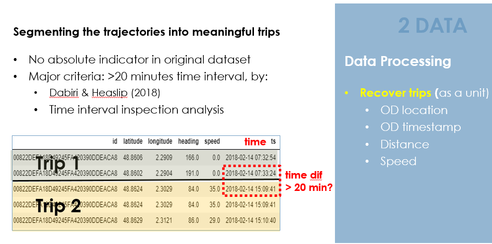

Renaming variables V2 V3 V4:

I called them “morning”,“day”,“night”.. But waiting confirmation about explanation of these variables (not the same in FCDM.pptx), plus: aux quelles heures àa corresponds?

```r
library(dplyr)
vehicle = vehicle %>% rename(morning = V2, night = V3, day = V4)
vehicle = vehicle %>% select(-vehicleId)
```

### transformation

- Calcul TotalDuration en heures et minutes
- AvgDuration (jours) en heures et minutes
- AvgWaiting (jours) en heures et minutes

```r
library(tidyverse)
library(tidylog)
vehicle = vehicle %>%
  mutate(TotalDurationHour = AvgDuration*NbrTrips*24,
         TotalDurationMinutes = AvgDuration*NbrTrips*24*60,
         AvgDurationHour = AvgDuration*24,
         AvgDurationMinutes = AvgDuration*24*60,
         AvgWaitingHour = AvgWaiting*24,
         AvgWaitingMinutes = AvgWaiting*24*60)
```

**Summary**

```r
library(skimr)
vehicle %>%
  skim()
```

Data summary

| Name | Piped data |
| --- | --- |
| Number of rows | 1711 |
| Number of columns | 14 |
| _______________________ |  |
| Column type frequency: |  |
| numeric | 14 |
| ________________________ |  |
| Group variables | None |

**Variable type: numeric**

| skim_variable | n_missing | complete_rate | mean | sd | p0 | p25 | p50 | p75 | p100 | hist |
| --- | --- | --- | --- | --- | --- | --- | --- | --- | --- | --- |
| morning | 0 | 1 | 2.24 | 2.82 | 0.00 | 0.00 | 2.00 | 3.00 | 21.00 | ▇▁▁▁▁ |
| night | 0 | 1 | 0.88 | 1.35 | 0.00 | 0.00 | 0.00 | 1.00 | 15.00 | ▇▁▁▁▁ |
| day | 0 | 1 | 1.31 | 2.08 | 0.00 | 0.00 | 0.00 | 2.00 | 20.00 | ▇▁▁▁▁ |
| NbrTrips | 0 | 1 | 4.43 | 2.91 | 2.00 | 2.00 | 4.00 | 5.00 | 25.00 | ▇▂▁▁▁ |
| AvgDuration | 0 | 1 | 0.01 | 0.01 | 0.00 | 0.00 | 0.01 | 0.01 | 0.07 | ▇▁▁▁▁ |
| AvgWaiting | 0 | 1 | 0.01 | 0.02 | -0.18 | 0.00 | 0.00 | 0.01 | 0.28 | ▁▇▆▁▁ |
| distDA | 0 | 1 | 30.61 | 30.41 | 0.00 | 8.13 | 20.65 | 43.07 | 203.75 | ▇▂▁▁▁ |
| meanRatio | 0 | 1 | 1.59 | 2.98 | 0.06 | 1.19 | 1.29 | 1.41 | 90.76 | ▇▁▁▁▁ |
| TotalDurationHour | 0 | 1 | 0.74 | 0.64 | 0.00 | 0.32 | 0.55 | 0.95 | 4.66 | ▇▂▁▁▁ |
| TotalDurationMinutes | 0 | 1 | 44.52 | 38.49 | 0.10 | 19.16 | 33.15 | 56.93 | 279.32 | ▇▂▁▁▁ |
| AvgDurationHour | 0 | 1 | 0.18 | 0.15 | 0.00 | 0.09 | 0.14 | 0.23 | 1.72 | ▇▁▁▁▁ |
| AvgDurationMinutes | 0 | 1 | 10.90 | 8.72 | 0.05 | 5.38 | 8.48 | 13.69 | 103.07 | ▇▁▁▁▁ |
| AvgWaitingHour | 0 | 1 | 0.22 | 0.45 | -4.38 | 0.03 | 0.08 | 0.24 | 6.81 | ▁▇▆▁▁ |
| AvgWaitingMinutes | 0 | 1 | 12.94 | 27.02 | -262.87 | 1.88 | 4.72 | 14.43 | 408.47 | ▁▇▆▁▁ |

The columns I want to include in the study: “morning”,“day”,“night”,“NbrTrips”,“AvgDuration**Hour**”,“AvgWaiting**Hour**”,“distDA”,“meanRatio”,“TotalDurationHour”

```r
colnames(vehicle)
```

```
##  [1] "morning"              "night"                "day"
##  [4] "NbrTrips"             "AvgDuration"          "AvgWaiting"
##  [7] "distDA"               "meanRatio"            "TotalDurationHour"
## [10] "TotalDurationMinutes" "AvgDurationHour"      "AvgDurationMinutes"
## [13] "AvgWaitingHour"       "AvgWaitingMinutes"
```

```r
features = c("morning","night","day","NbrTrips","AvgDurationHour","AvgWaitingHour","distDA","meanRatio","TotalDurationHour")
```

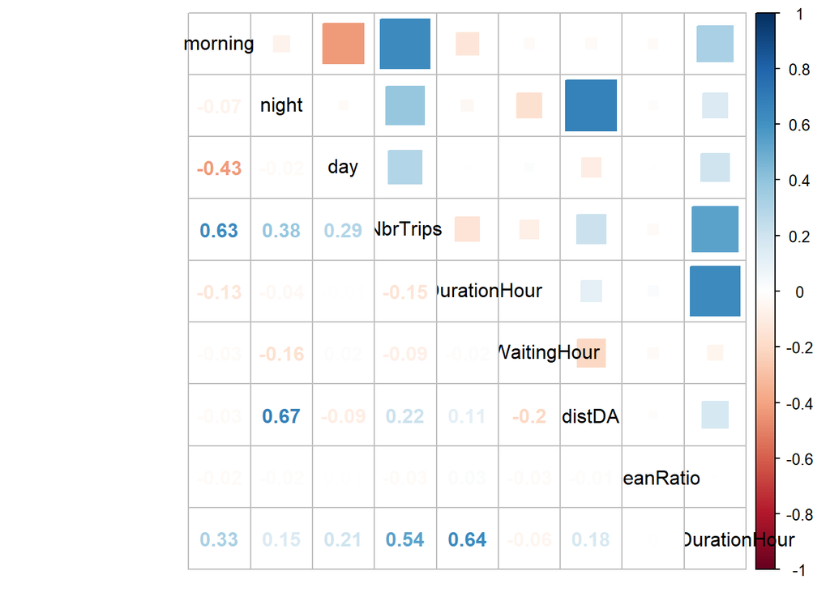

```r
M = cor(vehicle[,features])
corrplot::corrplot.mixed(M, upper = "square", tl.col = "black")
```

**About meanRatio**

**meanRatio** n’est corrélée avec aucune variable. Bizarre ? Regardons les nuages des points. ça montre des points extremes qui causent cette corrélaton nulle. A faire: identifier ces points s’ils s’agissent des mêmes vehicules, les traiter.

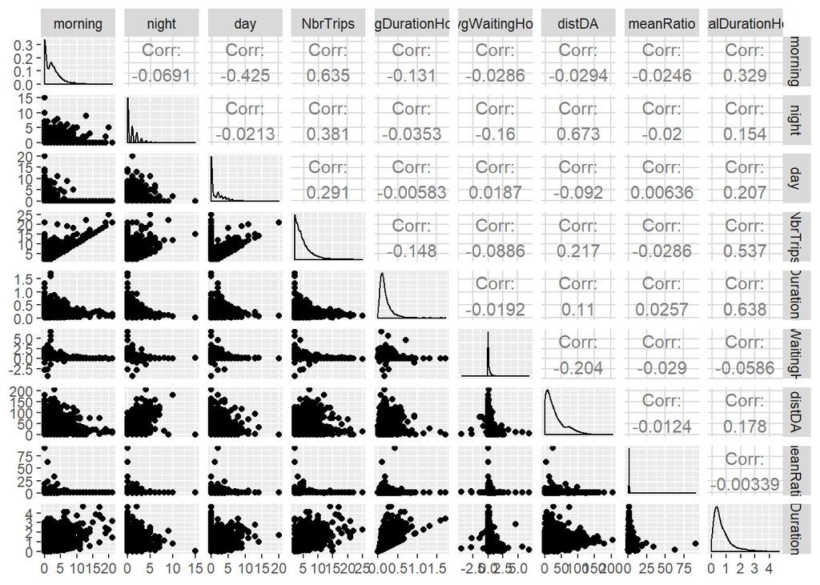

```r
# library(GGally)
# ggscatmat(vehicle)
GGally::ggpairs(vehicle[,features])
```

## New categorical variable

Classer voiture selon le max de trips par durée. Ok?

Calculating new variables to see colors, named **category**: morning or day or night with respect to max between them

```r
vehicle$category = as.factor(colnames(vehicle[,1:3])[apply(vehicle[,1:3],1,which.max)])
features = c(features, "category")
```

```r
plotly::plot_ly(vehicle, x=~morning, y=~day, z=~night, color=~category)
```

[interactive chart not shown]

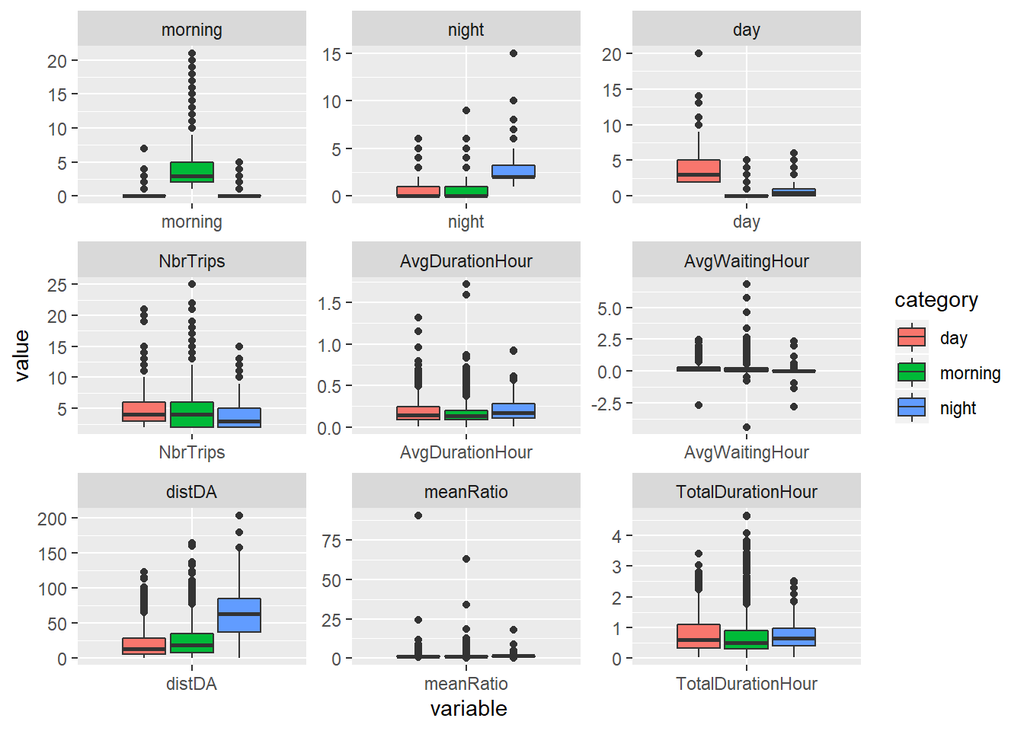

```r
vehicle_melted = reshape2::melt(vehicle[,features], id.var = "category")

p <- ggplot(data = vehicle_melted, aes(x=variable, y=value)) +
             geom_boxplot(aes(fill=category))
p + facet_wrap( ~ variable, scales="free")
```

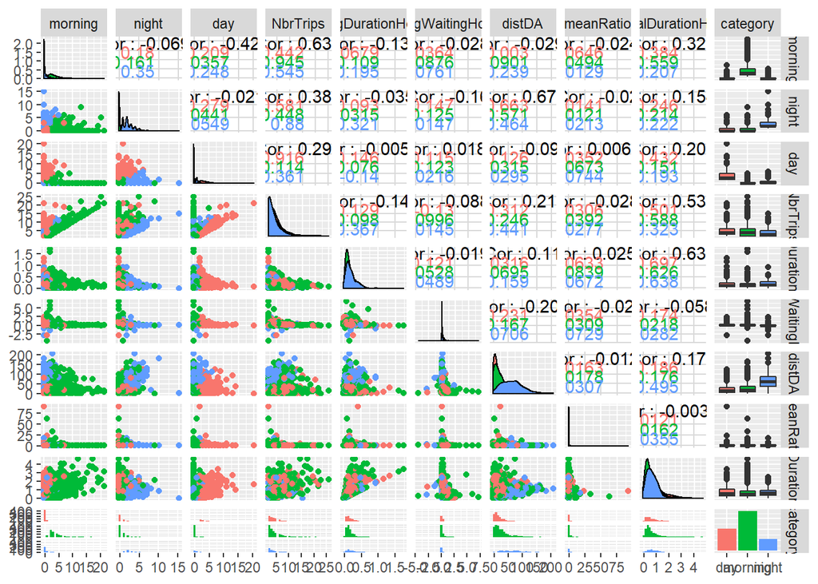

```r
# library(GGally)
# ggscatmat(vehicle)
GGally::ggpairs(vehicle[,features], mapping=ggplot2::aes(colour = category))
```

# Dim Reduction

## PCA

```r
library("FactoMineR")
library("factoextra")
res.pca = PCA(vehicle[,-15], graph = F)
get_eigenvalue(res.pca)
```

```
##          eigenvalue variance.percent cumulative.variance.percent
## Dim.1  4.258660e+00     3.041900e+01                    30.41900
## Dim.2  3.152948e+00     2.252106e+01                    52.94006
## Dim.3  2.260576e+00     1.614697e+01                    69.08703
## Dim.4  1.507545e+00     1.076818e+01                    79.85521
## Dim.5  1.331031e+00     9.507363e+00                    89.36257
## Dim.6  9.947973e-01     7.105695e+00                    96.46826
## Dim.7  3.170129e-01     2.264378e+00                    98.73264
## Dim.8  1.774302e-01     1.267359e+00                   100.00000
## Dim.9  1.391635e-28     9.940250e-28                   100.00000
## Dim.10 4.818850e-30     3.442036e-29                   100.00000
## Dim.11 5.300806e-31     3.786290e-30                   100.00000
## Dim.12 9.193901e-32     6.567072e-31                   100.00000
## Dim.13 4.224568e-32     3.017549e-31                   100.00000
## Dim.14 1.559004e-32     1.113574e-31                   100.00000
```

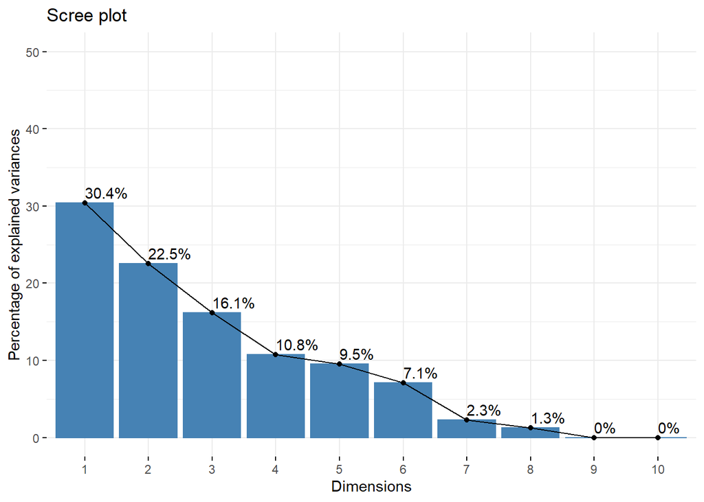

```r
fviz_eig(res.pca, addlabels = TRUE, ylim = c(0, 50))
```

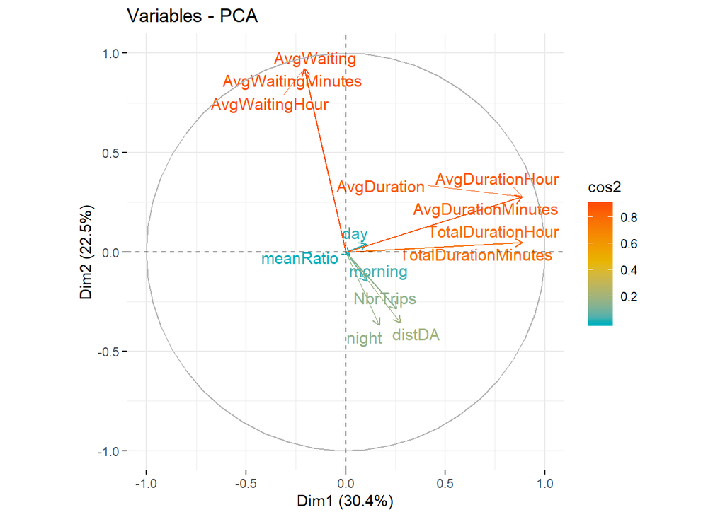

```r
fviz_pca_var(res.pca, col.var = "cos2",
             gradient.cols = c("#00AFBB", "#E7B800", "#FC4E07"),
             repel = TRUE # Évite le chevauchement de texte
             )
```

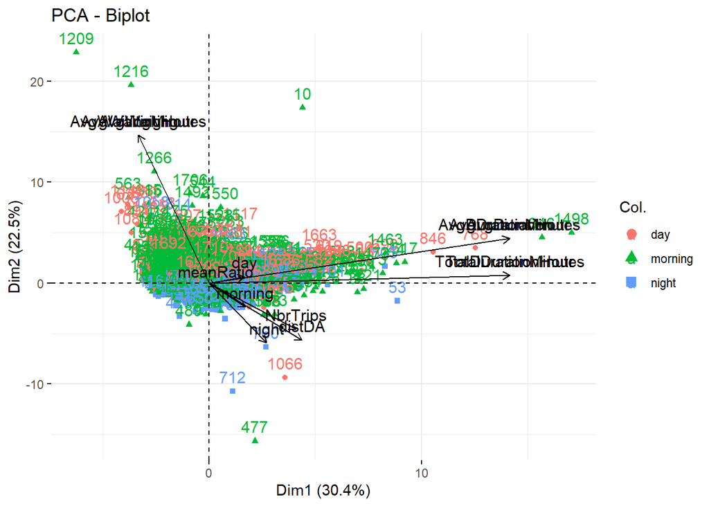

```r
fviz_pca_biplot(res.pca,
                col.var = "black", # Couleur des variables
                col.ind = vehicle$category  # Couleur des individues
                )
```

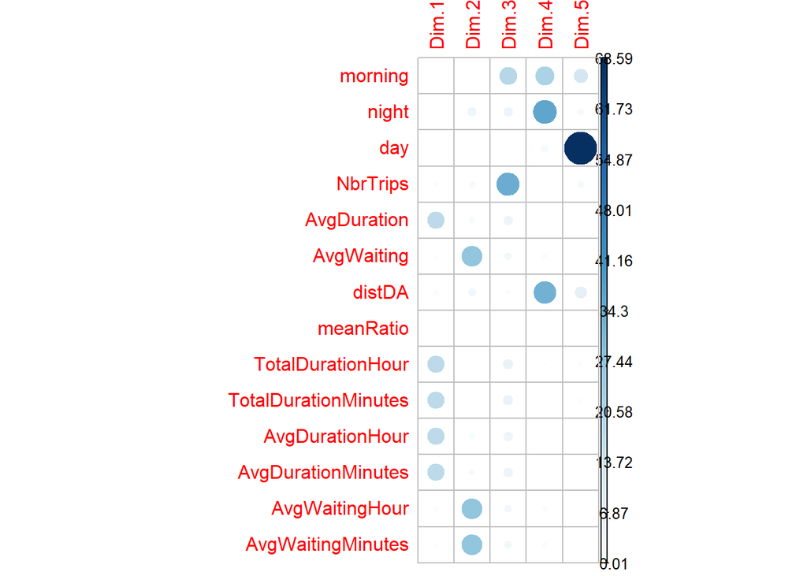

```r
var <- get_pca_var(res.pca)
corrplot::corrplot(var$contrib, is.corr=FALSE)
```

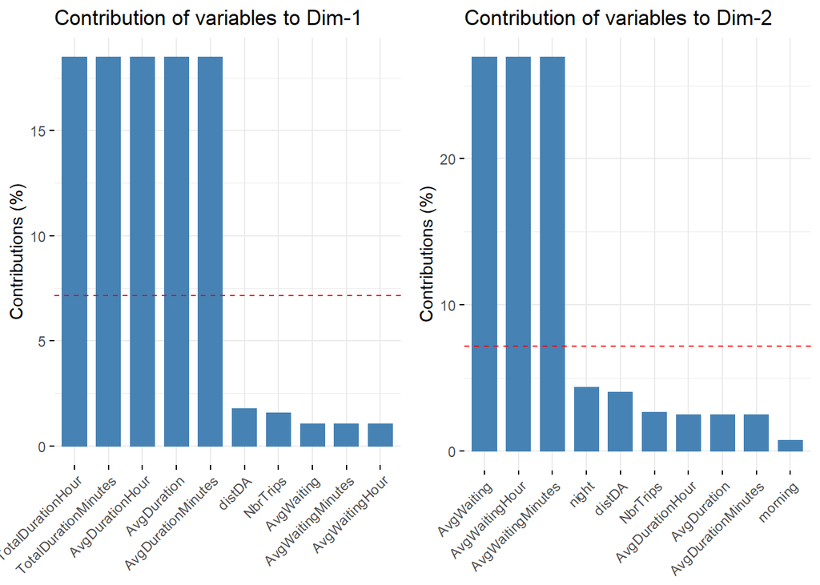

```r
# Contributions des variables à PC1
contrib1 = fviz_contrib(res.pca, choice = "var", axes = 1, top = 10)
# Contributions des variables à PC2
contrib2 = fviz_contrib(res.pca, choice = "var", axes = 2, top = 10)
gridExtra::grid.arrange(contrib1, contrib2, ncol=2)
```

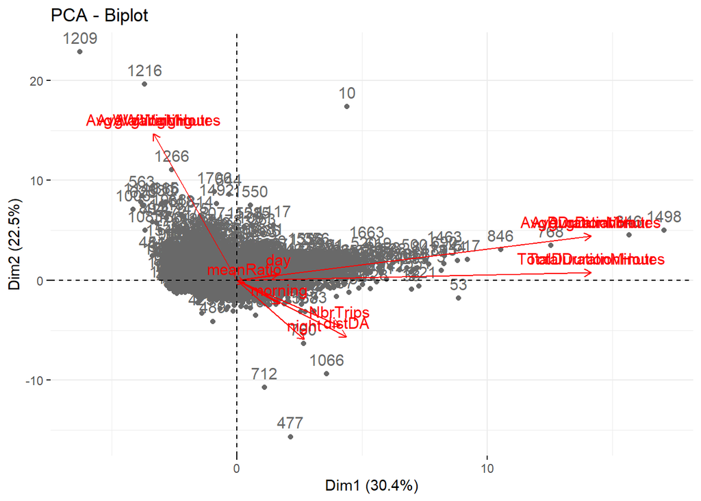

```r
fviz_pca_biplot(res.pca,
                col.var = "red", # Couleur des variables
                col.ind = "#696969"  # Couleur des individues
                )
```

## t-SNE

(t-SNE) t-Distributed Stochastic Neighbor Embedding is a non-linear dimensionality reduction algorithm used for exploring high-dimensional data.

```r
library(Rtsne)
tsne <- Rtsne(vehicle, dims = 2, perplexity=30, verbose=TRUE, max_iter = 500)
```

[output not shown]

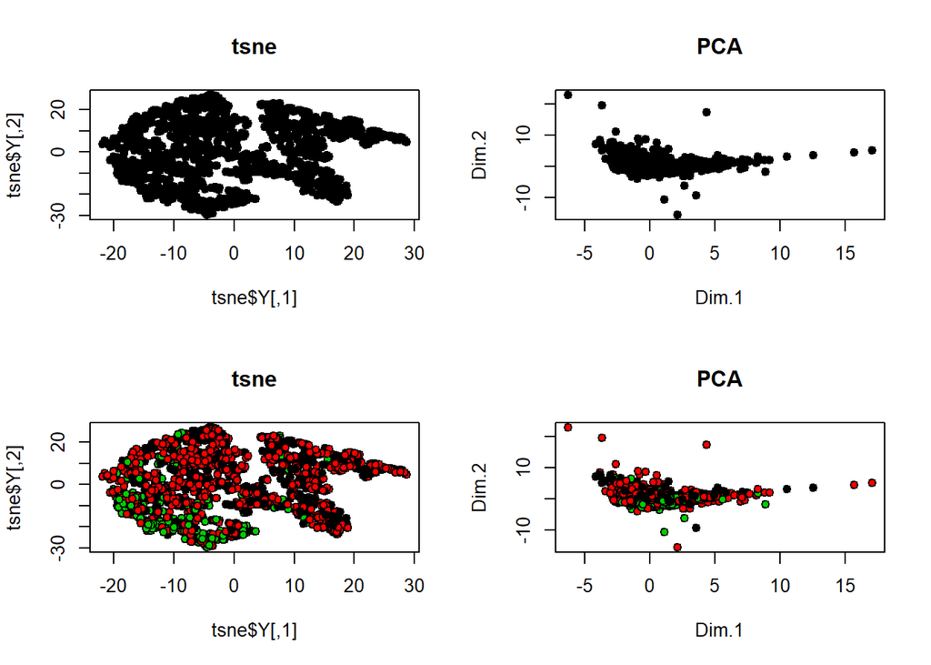

```r
par(mfrow=c(2,2))
plot(tsne$Y, main="tsne", pch=21, bg="black")
plot(res.pca$ind$coord[,1:2], main = "PCA", pch=21, bg="black")
plot(tsne$Y, main="tsne", pch=21, bg= vehicle$category)
plot(res.pca$ind$coord[,1:2], main = "PCA", pch=21, bg= vehicle$category) # color by category (highest number of trips
```

## Tourr

```r
# library(tourr)
# X11()     # Windows
# animate_xy(vehicle, axes = "off")
```

New pca, whithout variables “morning”,“date”,“night”

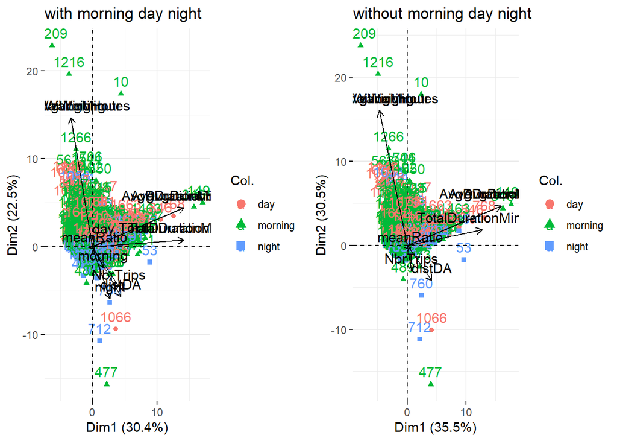

```r
new.pca = PCA(vehicle[,-c(1:3,9,15)], graph=F)
gridExtra::grid.arrange(
fviz_pca_biplot(res.pca,
                col.var = "black", # Couleur des variables
                col.ind = vehicle$category,  # Couleur des individues
                title = "with morning day night"),
fviz_pca_biplot(new.pca,
                col.var = "black", # Couleur des variables
                col.ind = vehicle$category,  # Couleur des individues
                title = "without morning day night"),
ncol=2)
```

Apparemment la présence de ces variables aide un peu, pas trop, ici.

```r
# manual scale figure
#
# library(tidyverse)
# library(tidylog)
#
# plot_data = as.data.frame(ac$scores[,1:2]) %>%
#   bind_cols(as_tibble(res.fcm$u)) %>%
#   pivot_longer(cols=starts_with('Cluster'), names_to='Cluster', values_to='Prob')
#
#
#
# plot_data = vehicle %>%
#   pivot_longer(cols=c(morning,day,night))
#
# ggplot(plot_data, aes(NbrTrips, distDA, color=name, alpha=value)) +
#   geom_point(size=2, shape=16) +
#   scale_color_manual(values=c(`morning`='red', `day`='green', `night`='blue')) +
#   guides(alpha='none') +
#   theme_minimal()
#
# p <- ggplot(vehicle, aes(NbrTrips, AvgDuration)) +
#   geom_point(aes(colour = factor(category)))
```

# Clustering

## kmeans

```r
features = features[-length(features)]
```

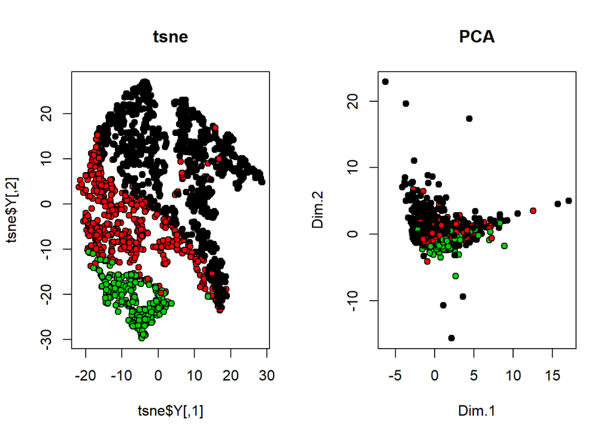

```r
set.seed(1812)
res.km = kmeans(vehicle[,features],3, nstart = 20)
par(mfrow=c(1,2))
plot(tsne$Y, main="tsne", pch=21, bg= res.km$cluster)
plot(res.pca$ind$coord[,1:2], main = "PCA", pch=21, bg= res.km$cluster) # color by category (highest number of trips
```

les clusters sont séparés dans la visualisation du tsne!

Regardant la répartition dans les clusters

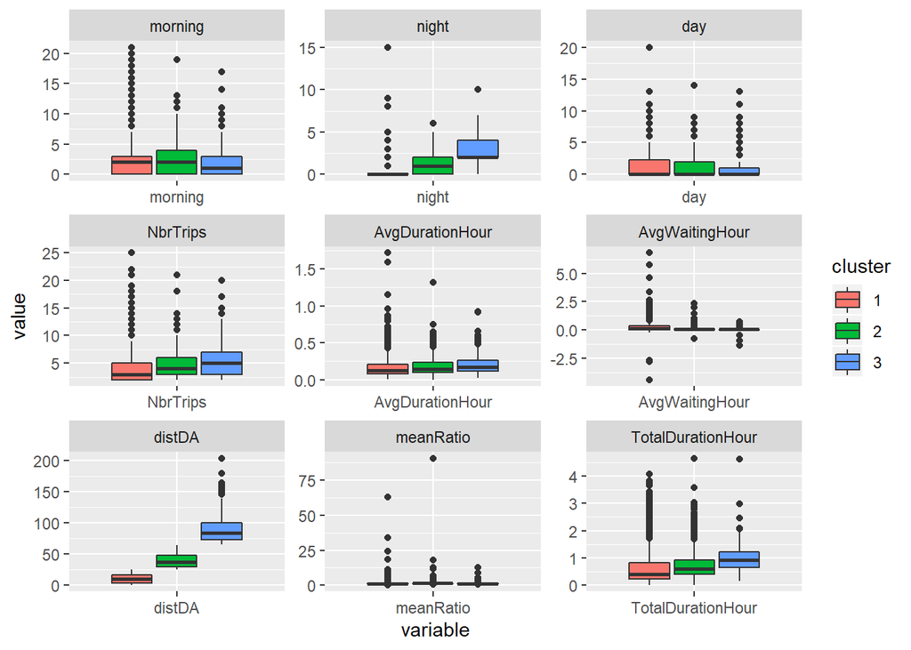

```r
vehicle_tomelt = add_column(vehicle, cluster = res.km$cluster)
vehicle_tomelt$cluster = as.factor(vehicle_tomelt$cluster)
features = c(features,"cluster")
vehicle_tomelt = vehicle_tomelt[,features]
vehicle_melted = reshape2::melt(vehicle_tomelt, id.var = "cluster")
vehicle_melted$cluster = as.factor(vehicle_melted$cluster)

p <- ggplot(data = vehicle_melted, aes(x=variable, y=value)) +
             geom_boxplot(aes(fill=cluster))
p + facet_wrap( ~ variable, scales="free")
```

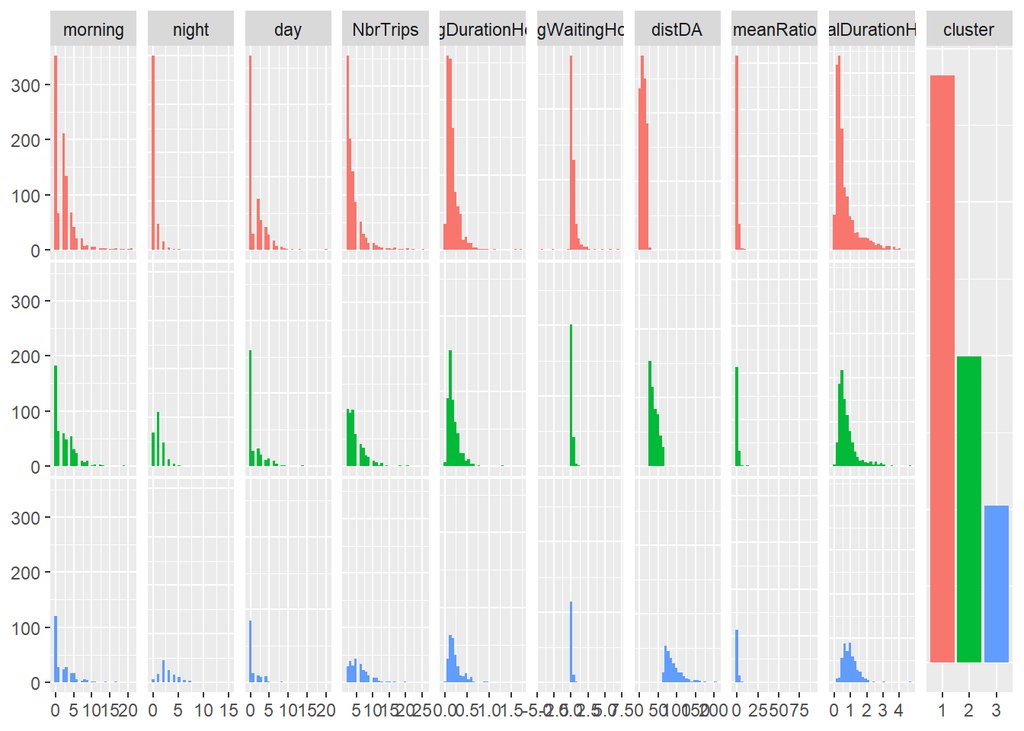

```r
p = GGally::ggpairs(vehicle_tomelt,mapping=ggplot2::aes(colour = cluster))
plots <- lapply(1:p$ncol, function(j) GGally::getPlot(p, i = 10, j = j))
GGally::ggmatrix(plots, nrow=1, ncol=10 , xAxisLabels = p$xAxisLabels[1:p$ncol])
```

## GMM

```r
features = c("morning","night","day","NbrTrips","AvgDurationHour","AvgWaitingHour","distDA","meanRatio","TotalDurationHour")
```

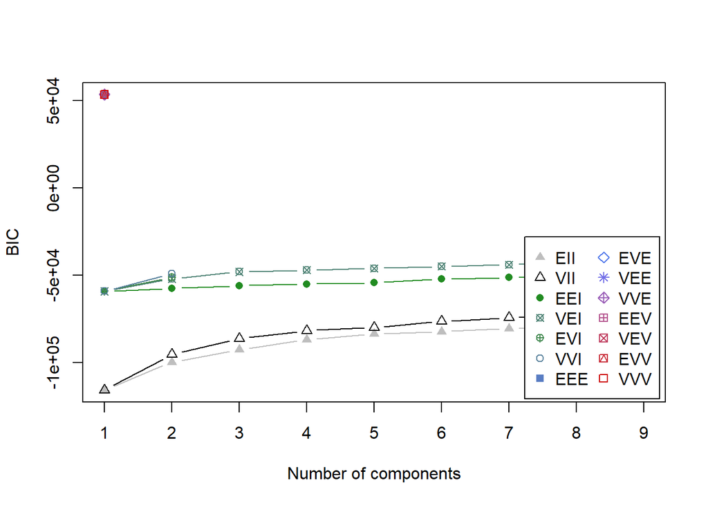

```r
library(mclust)
gmm <- Mclust(vehicle[,features])
plot(gmm, what = "BIC")
```

Si on laisse Mclust choisir automatiquement il choisit 1 cluster !

Essayons avec 3 ou 4 clusters (gaussiennes)

```r
gmm3 <- Mclust(vehicle[,features], G = 3)
table(gmm3$classification)
```

```
##
##   1   2   3
## 795  47 869
```

```r
gmm4 <- Mclust(vehicle[,features], G = 4)
table(gmm4$classification)
```

```
##
##   1   2   3   4
## 799 334  48 530
```

```r
gmm5 <- Mclust(vehicle[,features], G = 5)
table(gmm5$classification)
```

```
##
##   1   2   3   4   5
## 544 125  57 233 752
```

il y a toujours un cluster de minorité, environ 47 vehicules

Choisisson donc 3 clusters

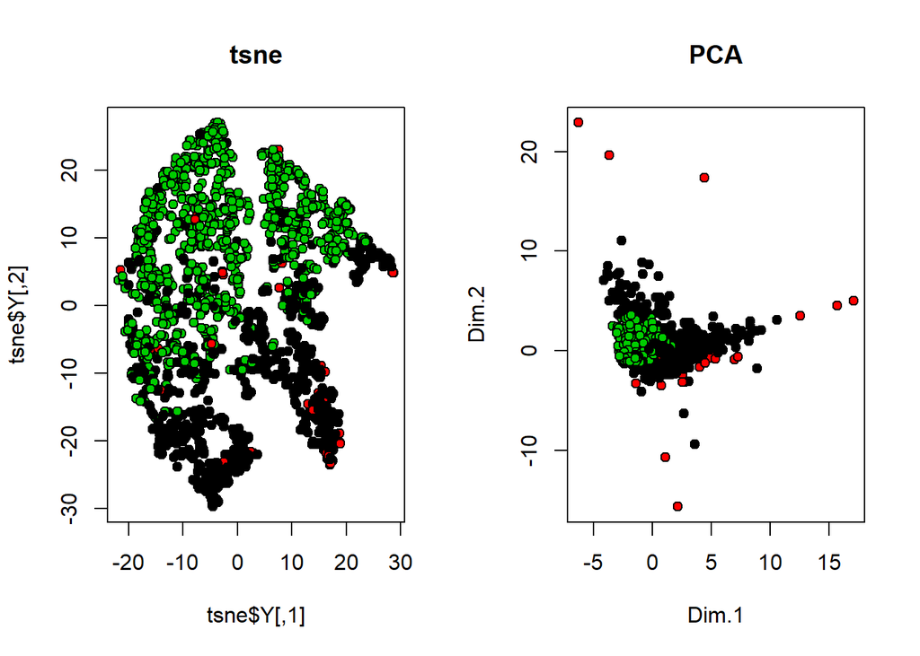

```r
par(mfrow=c(1,2))
plot(tsne$Y, main="tsne", pch=21, bg= gmm3$classification)
plot(res.pca$ind$coord[,1:2], main = "PCA", pch=21, bg= gmm3$classification) # color by category (highest number of trips
```

Si on regarde la figure à droite (acp) on voit que le cluster minoré est quand même intéressant, il s’agit des voitures extremes

Regardons le biplot

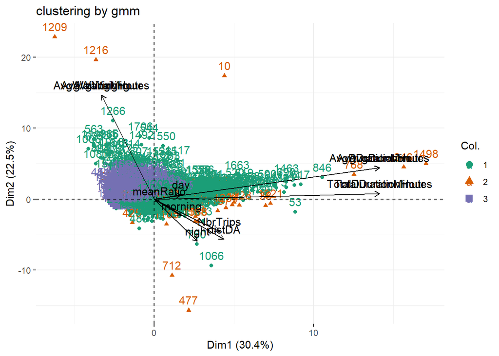

```r
p = fviz_pca_biplot(res.pca,
                col.var = "black", # Couleur des variables
                col.ind = as.factor(gmm3$classification),  # Couleur des individues
                title = "clustering by gmm")
p + scale_color_brewer(palette="Dark2")
```

Mmmmm ?

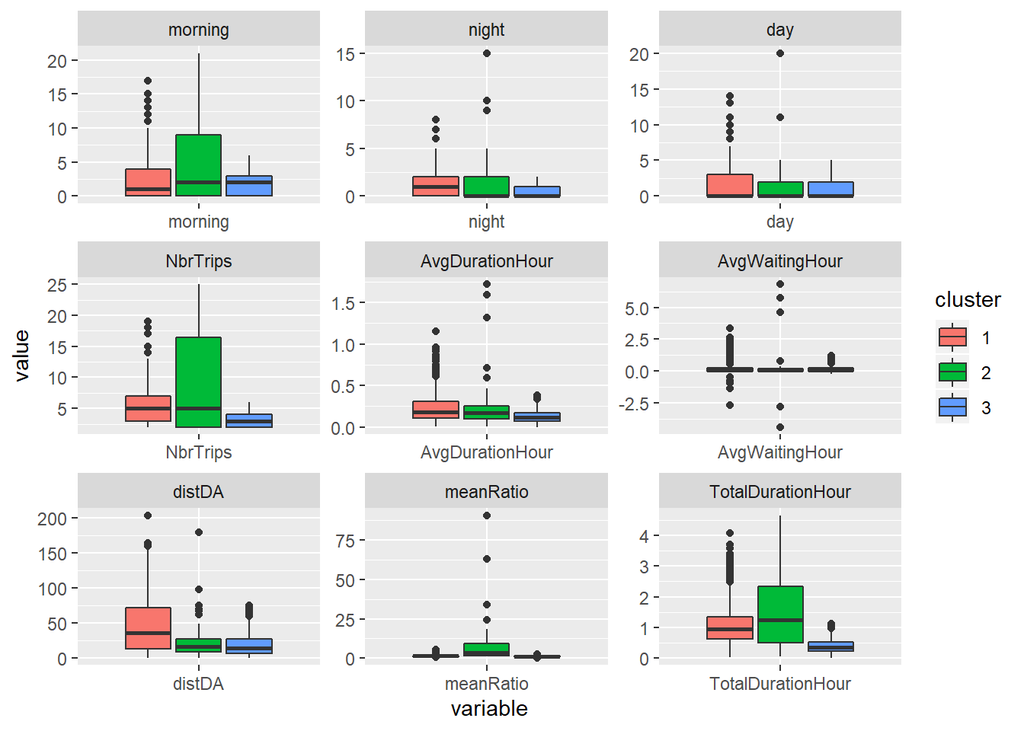

```r
vehicle_tomelt = add_column(vehicle, cluster = gmm3$classification)
vehicle_tomelt$cluster = as.factor(vehicle_tomelt$cluster)
features = c(features,"cluster")
vehicle_tomelt = vehicle_tomelt[,features]
vehicle_melted = reshape2::melt(vehicle_tomelt, id.var = "cluster")
vehicle_melted$cluster = as.factor(vehicle_melted$cluster)

p <- ggplot(data = vehicle_melted, aes(x=variable, y=value)) +
             geom_boxplot(aes(fill=cluster))
p + facet_wrap( ~ variable, scales="free")
```

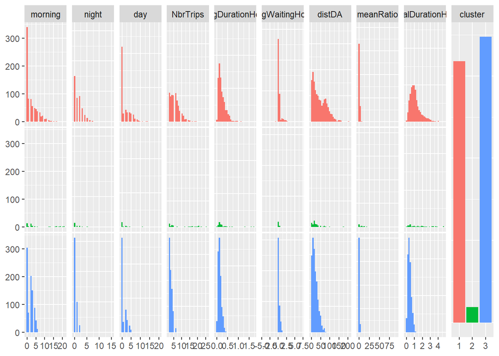

```r
p = GGally::ggpairs(vehicle_tomelt,mapping=ggplot2::aes(colour = cluster))
plots <- lapply(1:p$ncol, function(j) GGally::getPlot(p, i = 10, j = j))
GGally::ggmatrix(plots, nrow=1, ncol=10 , xAxisLabels = p$xAxisLabels[1:p$ncol])
```

D’autres méthodes de clustering.. possible de les appliquer si on souhaite

gtm som

Mesure de performance de clustering, en terme de séparation de clusters etc… : validity measures